# American Sign Language Image Gesture Recognition

Final Project

Author

Shaina W, Emily S, Yuka M

Published

March 22, 2024

Link to git repo: https://github.com/emilyrshi/PIC16B_Project_Repo.git

# Overview

We have created an image classification tool that reads in sign language letter data and classifies it to its corresponding alphabet letter. We aimed to complete this project because we saw it as an opportunity to create a tool to make the lives of the deaf, autistic, and other signing communities easier. There is a gap between those who need to sign, and those who do not know how to sign. We wanted our project to be a meaningful and productive tool that could be used to influence these communities, so we aimed to bridge that gap in communication. We wanted our image classifying demonstration to be able to take input of American Sign Language hand gestures and classify them into 7 classes. Our classes are limited to the letters in the phrase, “hello world”.

Our process began by us researching about how to process images to send through a model. We tried various techniques to do so including greyscaling and using Gaussian filters. We thought of various methods to collect our data and process it as well. We thought initially to create numpy arrays of the images and then turn them into dataframes to be passed through the models. We also initially thought to soley rely on datasets available online, but after searching through the ones that existed, we decided to take ones ourselves using the cv2 image capture. Eventually, we came to the idea of turning our images into a CSV file, so that large data could be sent through.

Then, we began to develop our models. We created multiple potential models and eventually decided on the TensorFlow Keras Sequential model as the main one that we would aim to refine. Through a process of trial and error, we were able to get our own images that we took into the model and produce a prediction for the letter. Our accuracy on that model was about 83%. Then, we wanted to utilize a pre-existing model and run our data through it in order to see how it would perform in comparison to the TensorFlow Keras Sequential model. We researched through 4-5 pre-existing models, attempted to send our csv through them, debugged them, and compared their accuracies. Among the multiple pre-existing models we tried, the resnet18 model came on top with an accuracy of around 70%. We decided on resnet18 to be our pre-existing model that we would send our data through to predict.

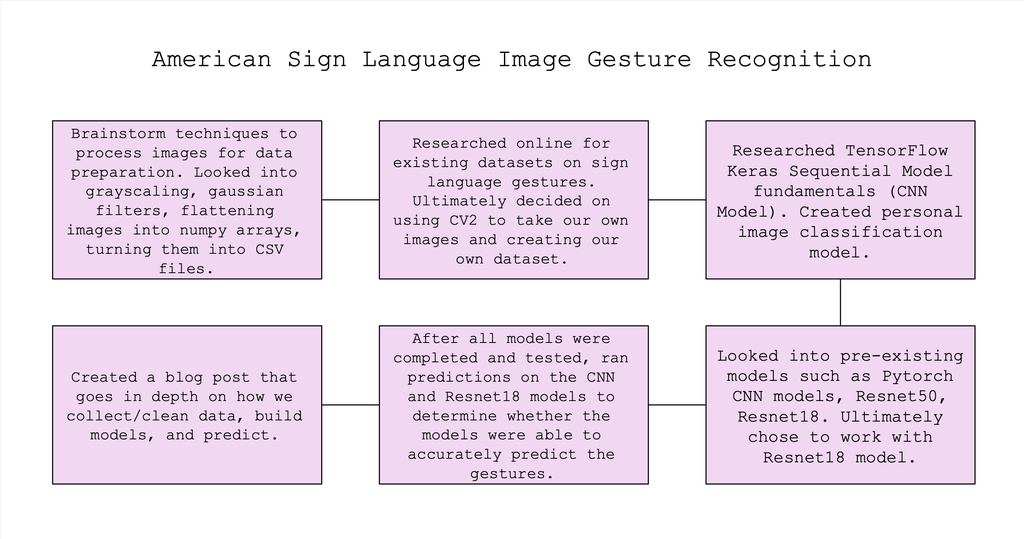

Screen Shot 2024-03-22 at 12.47.43 AM.png

# How to Run the Models

[figure not shown]

Screen Shot 2024-03-21 at 3.47.46 PM.png

# Technical Component #1: “Messy” and/or large data (i.e. no 1000 row csv file from kaggle that fits in laptop memory).

The first step of collecting data for our dataset is to figure out a way to collect images from our computer. We referenced a youtube video tutorial to collect 100 images per each of the 7 letters in “hello world”. We credit Nick Renotte for the code that he included in his YouTube video on how to use cv2 to capture hand guesture images. The links to his YouTube video and GitHub repository are as follows, respectively. https://www.youtube.com/watch?v=pDXdlXlaCco https://github.com/nicknochnack/RealTimeObjectDetection.gitBelow. With this we ended up with 100 images per letter in folders on our local computer.

In the github repository, you will see a folder called **“Data Cleaning and Collection”**. Inside the folder, there are two packages: image_capture.py and image_to_pixel.py.

**image_capture.py**

This packages allows users to easily call a function called *collect_images* to capture all the ASL gestures they would like to take on their personal webcame and easily store it onto their computer. The function takes in three parameters: labels, num_img, and img_path.

*labels:* name of the subfolders (list of string or int)

*num_img:* number of images per gesture (int)

*img_path:* name of the main folder (string)

After running the function and taking all images, the user will be able to see a folder in their Finder (MAC users) or File Explorer (PC users) with the name you have put in for the img_path. Inside the main folder, it will contain subfolders with the labels you have used. Inside these subfolders contain all the images you have collected corresponding to that specific label.

**Below is the code for the collect_images function:**

```python
def collect_images(labels, num_img=100, img_path='CollectedImages'):
    """
    Taking pictures using your own personal webcame
    A pop up will open on your screen and camera will turn on

    Arguments to function
    - labels: the american sign language gestures you would like to capture
    - num_img: the number of imagers per gestures
    - img_path: the name of the folder to store your iamges

    Return:
    - a new folder with all the captured images will be saved to your computer
    - If you have named your img_path 'CollectedImages', you will see a folder called CollectedImages.
        Inside, you will see sub folders named with the labels you have used.
        Within the sub folders will be all the images you have captured.

    ***
    We would like to thank Nick Renotte for his youtube tutorial on how to collect images using our personal webcams.
    His youtube video and well as his github, which we have pasted below:
    https://www.youtube.com/watch?v=pDXdlXlaCco
    https://github.com/nicknochnack/RealTimeObjectDetection.git
    ***
    """
    # Loop through each of the labels in the labels array
    for label in labels:
        # Create a directory for each label
        label_directory = os.path.join(img_path, label)
        os.makedirs(label_directory, exist_ok=True)

        # Beginning video capture (should see a popup on the computer screen)
        cap = cv2.VideoCapture(0)
        print('Collecting images for {}'.format(label))

        # Allows for 5 seconds to change positions when capturing images
        time.sleep(5)

        # Looking at whether the webcam capture works
        if not cap.isOpened():
            print("Error: Could not open webcam")
            break

        # Taking the amount of images we set above, which is 100 images per letter
        for imgnum in range(num_img):
            # Setting up the frame for our images
            ret, frame = cap.read()

            if ret:
                # Creating the name of our image file
                imgname = os.path.join(label_directory, label + '_' + str(uuid.uuid1()) + '.jpg')

                # Adding the images into our directory
                cv2.imwrite(imgname, frame)

                # Displaying the image on our screen to see what we have taken
                cv2.imshow('frame', frame)

                # Pauses to get into another pose
                time.sleep(2)

            # Looking at whether the user wants to quit taking images
            if cv2.waitKey(1) & 0xFF == ord('q'):
                break

        # Finishes the capture of image for a letter
        cap.release()

    # Closes the camera popup window
    cv2.destroyAllWindows()
```

**image_to_pixel.py**

This package contains a function called *image_processing*, which allows users to easily convert the images they have captured into a dataframe of image features. The function takes in three parameters: main_folder, sub_folder, and letters.

*main_folder:* path to the main folder where all the images are saved from the image capture

*sub_folder:* list of sub folder titles within the main folder

*letters:* list of letters corresponding to each sub folder title

After running the function, a dataframe will be produced consisting of 785 columns. All images are converted into grayscale and resized to 28 by 28, resulting in 784 columns of pixel data. The additional column is called ‘Letters’, which corresponds to which letter each row of the dataframe corresponds to.

**Below is the code for the image_processing function:**

```python
def image_processing(main_folder, sub_folder, letters):
    """
    Cleaning the images and creating a dataframe of image features

    Arguments to function:
    - main_folder: path to the main directory where all images are save from the image capture
    - sub_folder: list of sub folder titles within the main folder
    - letters: list of letters corresponding to each sub folder title

    Returns:
    - df: dataframe containing flattened arrays of processed images
    """
    # Initialize an empty DataFrame
    df = pd.DataFrame()

    # Loop through each folder title
    for sub_title in sub_folder:
        # Combining the main folder and sub folder together
        folder_dir = os.path.join(main_folder, sub_title)
        # If this folder directory exists we continue to for loop
        if os.path.isdir(folder_dir):
            # Loop through the images in the directory
            for filename in os.listdir(folder_dir):
                # Check if the file ends with .jpg
                if filename.endswith(".jpg"):
                  # Read the image
                  image_path = os.path.join(folder_dir, filename)
                  letter_img = cv2.imread(image_path)

                  # Converting the image into grayscale
                  letter_gray = cv2.cvtColor(letter_img, cv2.COLOR_BGR2GRAY)

                  # Resize the image
                  letter_gray = cv2.resize(letter_gray, (28, 28), interpolation=cv2.INTER_LINEAR)

                  # Convert the image to a NumPy array
                  np_array = np.array(letter_gray)

                  # Flatten the array
                  flattened_array = np_array.flatten()

                  # Append the flattened array to the DataFrame
                  df = df.append(pd.Series(flattened_array), ignore_index=True)

            # # Add a column with the specified letter for all rows
            df.loc[df.index[df.shape[0] - len(os.listdir(folder_dir)):], 'Letters'] = letters[sub_title.index(sub_title)]

    return df
```

## Example of how to use these two packages in your code

To see how these two functions work together in data cleaning and acquisition, you can find another file in the same Data Cleaning and Collection called data_acquisition_cleaning.ipynb.

**Below is the same code contained in the github file:**

I will walk through the code in more detail.

First, let’s import all the required libraries and the packages.

```python
from google.colab import drive # optional
import os # optional
import cv2
import numpy as np
import pandas as pd

# Self-created packages
import image_capture
from image_capture import collect_images
import image_to_pixel
from image_to_pixel import image_processing
```

Next, let’s go over how we can use the collect_images function.

First create a variable called labels, which consists of the letters or the gestures you would like to capture. Next, define a variable called num_img. This will be the number of images you will take for each letter. Finally, define a variable called img_path, which will be the name of the main folder.

Now, you can put all the information into collect_images.

```python
# Letters of gestures we will be taking pictures of (change to whatever you would like)
labels = ['h', 'e', 'l', 'o', 'w', 'r', 'd']

# Select the number of images you would like to take for each letter
num_img = 50 # default is set to 100

# Select the name of the folder you would like the images to be stored in
img_path = 'SignLanguageGestures' # default is set to 'CollectedImages'

collect_images(labels, num_img, img_path)
```

Once you run the function, expect to see a pop up screen appear on your computer. Once the pop up screen appears it will begin to take pictures so make sure you have your first pose ready!

While the function is running it will tell you which letter they are collecting images of. For example, it will output a line, “Collecting images for h” so make sure you are in position of h. Once it is capturing images for the next letter it will output another line of “Collecting images for…”.

Once all images are collected the pop up screen will automitically exit. However, in the middle of running the function, if you accidentally use the wrong gesture or feel tired and will like to terminate, you can press q to quit.

Once all images have been captured, we are now ready for the data cleaning process! First, make sure you have the pathway to where the folder is stored. Be sure to change the code below as it will be different for everyone!

```python
# CHANGE THE CODE BELOW TO DIRECT TOWARD WHERE THE IMAGES YOU HAVE CAPTURED IS STORED
# In our example, our images have been stored in our google drive
drive.mount('/content/drive')
os.chdir('/content/drive/My Drive/PIC16B_PROJ/CollectedImages')
```

Once we got the path, we can use the image_processing function to clean our images and convert it into a dataframe.

Let’s define a few variables to pass through our function. First, you should use the same labels you used in the collect_images function. The labels correspond to the sub folders, so we want to ensure we are accessing the correct folders when running the function. Next, you can use the same labels of define different ones for the dataframe. These letters will be the ones appearing on the dataframe in the column ‘Letters’, which corresponds to the letter each row represents. Finally, we want to define a variable called main_folder, which specifies the path to the main folder where all the images are stored. This will typically be the path to the ‘CollectedImages’ or what you decided to name your folder from the previous function.

```python
# Use the same labels you used for the collect_images function to ensure you are accessing the right folders
labels = ['h', 'e', 'l', 'o', 'w', 'r', 'd']

# Can use the same or different labels for the dataframe
# These letters below will be the ones appearing on the dataframe in a column 'Letters'
letters = ['H', 'E', 'L', 'O', 'W', 'R', 'D']

# Specify the path to the main folder where all the images are stored
main_folder = '/content/drive/My Drive/PIC16B_PROJ/CollectedImages'

df = image_processing(main_folder, labels, letters)
```

Now we have created a dataframe using the image_processing function! If you would like to save the dataframe to a csv file, you can do so by running the codeblock below.

```python
df.to_csv('sign_language_dataset.csv')
```

We are now ready to move on to the next steps, which is model training and test!

# Technical Component #2: In-depth critical discussion of your machine learning model’s performance.

Under the **Models** folder in the github repository, you can find our CNN model that we created. You can download the the py file and follow along!

Below I will be going into the code in more detail.

First, let’s import all the necessary libraries needed.

```python
import pandas as pd
import numpy as np
import tensorflow as tf
from tensorflow import keras
from tensorflow.keras import datasets, layers, models
from sklearn.preprocessing import LabelEncoder
from sklearn.model_selection import train_test_split
import matplotlib.pyplot as plt
from keras.models import load_model
from keras.preprocessing import image
import matplotlib.pyplot as plt
import cv2

from google.colab import drive # optional
import os # optional
```

We have uploaded a csv file of the image features. Feel free to use the same csv file for this demo and you can import it using the same codechunk below. I have outputted the head of the csv file, so you can get an idea of what the csv file looks like!

```python
sign_language_url = "https://raw.githubusercontent.com/emilyrshi/PIC16B_Project_Repo/6e27757ed9a716812ef7acfc855be8521285a464/SignLanguage_CSV/sign_language_dataset.csv"

sign_language_data = pd.read_csv(sign_language_url, index_col = False)
sign_language_data.head()
```

|  | Unnamed: 0 | 0 | 1 | 2 | 3 | 4 | 5 | 6 | 7 | 8 | ... | 775 | 776 | 777 | 778 | 779 | 780 | 781 | 782 | 783 | Letter |
| --- | --- | --- | --- | --- | --- | --- | --- | --- | --- | --- | --- | --- | --- | --- | --- | --- | --- | --- | --- | --- | --- |
| 0 | 0 | 58 | 57 | 58 | 57 | 58 | 57 | 109 | 60 | 60 | ... | 196 | 81 | 31 | 22 | 16 | 13 | 9 | 7 | 6 | D |
| 1 | 1 | 58 | 58 | 58 | 58 | 57 | 57 | 108 | 59 | 58 | ... | 195 | 184 | 33 | 21 | 16 | 13 | 9 | 7 | 6 | D |
| 2 | 2 | 59 | 57 | 57 | 57 | 58 | 58 | 107 | 60 | 59 | ... | 197 | 190 | 34 | 21 | 18 | 14 | 9 | 7 | 6 | D |
| 3 | 3 | 60 | 60 | 60 | 59 | 58 | 59 | 110 | 61 | 60 | ... | 49 | 36 | 26 | 20 | 16 | 14 | 10 | 8 | 6 | D |
| 4 | 4 | 60 | 59 | 60 | 60 | 60 | 60 | 110 | 62 | 61 | ... | 41 | 31 | 24 | 19 | 17 | 14 | 10 | 8 | 7 | D |

5 rows × 786 columns

After importing the csv file or using the dataframe you created in the previous section, let’s begin splitting our data for training and testing.

We want to first seperate our data into image features and target labels. We will be defining a X variable consisting of columns 1:785, which will contain all of the pixel data. The Y variable will contain all the letters. Next, we need to convert both X and y into X and y.

We want to reshape all the input features into a 4 dimensional tensor. The -1 corresponds to the batch size of X. Batch size corresponds to the number of images we will be processing. Remember in the image_processing function, we resized all the images to 28 by 28. Thus, the 28 and 28 parameteres are indicating the dimensions of the images. Finally, the last parameter, 1, shows that the images are grayscaled images.

Next, we want to convert the target labels to one-hot encoding. One-hot encoding is used to generate a matrix and is commonly used for categorical variables. The rows correspond to the number of imagesm while the columns correspond to the letters. If the row represents a specific letter, the number will be a 1. If the row does not represent that letter, the number will be a 0. Below the codechunk, I have outputted what the one-hot encoding looks like.

After preforming the data cleaning, we are ready to split the data into training and validation.

```python
# Separate image features and target labels
X = sign_language_data.iloc[:, 1:785]
y = sign_language_data['Letter']

# Converting data to numpy arrays
X = X.to_numpy()
y = y.to_numpy()

# Reshape input features into 4 dimensional tensor
X = X.reshape(-1, 28, 28, 1)

# Convert target labels to one-hot encoding
y = pd.get_dummies(y)
print(y)
y = y.to_numpy()

# Split the dataset into training and validation sets
X_train, X_val, y_train, y_val = train_test_split(X, y, test_size=0.2, random_state = 42) # random_State = 42
```

```
     D  E  H  L  O  R  W
0    1  0  0  0  0  0  0
1    1  0  0  0  0  0  0
2    1  0  0  0  0  0  0
3    1  0  0  0  0  0  0
4    1  0  0  0  0  0  0
..  .. .. .. .. .. .. ..
695  0  0  0  0  0  0  1
696  0  0  0  0  0  0  1
697  0  0  0  0  0  0  1
698  0  0  0  0  0  0  1
699  0  0  0  0  0  0  1

[700 rows x 7 columns]
```

## What is a CNN Model?

Convolutional Neural Network, also commonly known as CNN, is a type of deep neural network. CNN is commonly used in computer vision and consists of three layers: input, hidden, and output. First, the model will take in an image into the input layer, which is passed through by a three dimensional matrix, which consist of the dimensions of the image and the last dimension is the color of the image. In our case, the input layer would look like (28, 28, 1). The 28 and 28 is the size of the image after using the image_processing function. The 1 corresponds to the images being in grayscale. After the input layer, the information gets passed through multiple hidden layers.

**Types of Hidden Layers:**

*Convolution Layer:* This layer will take the matrix of pixels we have passed through the input layer from the specific images we are analyzing. The output of the convolution layer is a new matrix where it takes the weighted average of the a pixel and the some of the other pixels surrounding it. This helps to make the unique features stand out for the model to easily tell the images apart.

*MaxPooling Layers:* This layer is used to decrease the dimensions. For example, if we are doing MaxPooling2D((2,2)), this means we are decrease each 2 by 2 pixels (total of 4 pixels) to 1 single pixel. This is commonly called downsampling or subsampling, which is decrease the size of the input, but also keeps the image features.

*Flatten Layer:* Commonly after convolution and maxpooling layers and before adding dense layers, you want to flatten the feature maps. We are turning all the information into a one-dimensional vector. Flattening is essential as it keeps all the important image features even after converting to a one-dimensional vector, but it also helps with overfitting in the model as the amount of parameters are reduced.

*Dense Layer:* This layer is in charge of connecting all neurons in the current layer is connected to all the neurons in the previous layer.

*Dropout Layer:* This layer is preventing overfitting as it is introducting noise to the model. In the previous layer, some neurons are temporaily dropped so the model will able to learn better with some information missing.

Those are the most common layers used in CNN models. In each of those models, you will also see a parameter called activation. A common activation that is used is relu. ReLU is used to determine whether a neuron should be turned off or on. In addition, it helps with overfitting and works similarly to the dropout layer.

Now that you are an expert in CNN models, let’s move on to the models we have created!

## CNN Model One

```python
cnn_one_model = models.Sequential([
    layers.Conv2D(32, (3, 3), activation='relu', input_shape=(28, 28, 1)),
    layers.MaxPooling2D((2, 2)),
    layers.Conv2D(64, (3, 3), activation='relu'),
    layers.MaxPooling2D((2, 2)),
    layers.Conv2D(128, (3, 3), activation='relu'),
    layers.Flatten(),
    layers.Dense(128, activation='relu'),
    layers.Dense(7, activation='softmax')  # number of classes (7 letters)
])
```

When compiling the model, you want to make sure you set the loss to categorical_crossentropy. This is used when the there are multiple-classes you are trying to work with and when the activation on the output layer is softmax.

```python
# Compiling the model
cnn_one_model.compile(optimizer='adam', loss='categorical_crossentropy', metrics=['accuracy'])

cnn_one_history = cnn_one_model.fit(X_train, y_train, epochs=20, validation_data=(X_val, y_val))
```

After running the model, let’s get a visual representation on the accuracy of the model.

```python
plt.plot(cnn_one_history.history["accuracy"], label = "training")
plt.plot(cnn_one_history.history["val_accuracy"], label = "validation")
plt.gca().set(xlabel = "epoch", ylabel = "accuracy")
plt.legend()
```

[figure not shown]

With this model, we do get accuracy as high as 85% which is pretty impressive. However, when looking at the plot, there seems to be some overfitting. You can tell there is overfitting when the accuracy of the training is higher than the accuracy of the validation. This means that the model may be taking in a lot of noise and unnecessary features. Let’s see if we can fix some layers in our model to get rid of the issue.

## CNN Model Two

```python
cnn_two_model = models.Sequential([
    layers.Conv2D(32, (3, 3), activation='relu', input_shape=(28, 28, 1)),
    layers.MaxPooling2D((2, 2)),
    layers.Conv2D(64, (3, 3), activation='relu'),
    layers.MaxPooling2D((2, 2)),
    layers.Conv2D(128, (3, 3), activation='relu'),
    layers.MaxPooling2D((2, 2)),
    layers.Flatten(),
    layers.Dense(256, activation='relu'),
    layers.Dropout(0.5),
    layers.Dense(128, activation='relu'),
    layers.Dense(7, activation='softmax')
])
```

With this new model, we have added additional dense layers and a dropout layer. This may help the model form more connections with the previous layers in the model and increasing model complexity leading to a higher accuracy. In addition, with the help of the dropout layer, it could potentially help with the problem of overfitting. Let’s run the model and see what happens!

```python
# Compiling the model
cnn_two_model.compile(optimizer='adam', loss='categorical_crossentropy', metrics=['accuracy'])

cnn_two_history = cnn_two_model.fit(X_train, y_train, epochs=20, validation_data=(X_val, y_val))
```

```python
plt.plot(cnn_two_history.history["accuracy"], label = "training")
plt.plot(cnn_two_history.history["val_accuracy"], label = "validation")
plt.gca().set(xlabel = "epoch", ylabel = "accuracy")
plt.legend()
```

[figure not shown]

From the plot, we can see that overfitting seems to be slightly better. However, the accuracy of our model decreased a lot. The highest accuracy was around 67.86%. Let’s see if we can play around with our model a little bit more too see if we can get rid of overfitting and increase our accuracy.

## CNN Model Three

```python
cnn_three_model = models.Sequential([
    layers.Conv2D(32, (3, 3), activation='relu', input_shape=(28, 28, 1)),
    layers.MaxPooling2D((2, 2)),
    layers.Conv2D(64, (3, 3), activation='relu'),
    layers.MaxPooling2D((2, 2)),
    layers.Flatten(),
    layers.Dropout(0.5),
    layers.Dense(128, activation='relu'),
    layers.Dense(7, activation='softmax')
])
```

In this new model, we decided to remove one convolutional layer and one dense layer from model two. In removing those two layers, we believe it could help reduce overfitting. Since these two layers have a lot of parameters, it may cause our model to overfit since we are only working with data of 700 images. In additional, it will also help the model to run a lot faster since the complexity of the model decreases. Let’s run our model and see if it is any better than the two previous models we have created!

```python
# Compiling the model
cnn_three_model.compile(optimizer='adam', loss='categorical_crossentropy', metrics=['accuracy'])

cnn_three_history = cnn_three_model.fit(X_train, y_train, epochs=20, validation_data=(X_val, y_val))
```

```python
plt.plot(cnn_three_history.history["accuracy"], label = "training")
plt.plot(cnn_three_history.history["val_accuracy"], label = "validation")
plt.gca().set(xlabel = "epoch", ylabel = "accuracy")
plt.legend()
```

[figure not shown]

With all three models, how do we decide which one to use on our testing dataset? Let’s do an overview of our model.

**First Model:** With our first model, we received the highest accuracy of 85%. However the issue with overfitting was pretty severe. We need to take the overfitting seriously as it causes a great affect when testing our model on unseen data. If the model is skewed based on the training dataset, it could preform very poorly on unseen data making the accuracy very low when we test it on our testing dataset.

**Second Model:** Our second model did a lot better in overfitting, though it was still prevelant as we could observe in the plot. However, with the added layers it drove the accuracy of our model down significantly. Thought we could use this model on our testing dataset, we created a third model to see if we could bring the accuracy up.

**Third Model:** Looking at the plot of the third model, we observed no signs of overfitting. We were also able to achieve a accuracy of 83.57%, which performs better than our second model but not better than the first model.

Overall when comparing these three models, we should use our third model on our unseen testing data. The reason is becaues there is no signs of overfitting in the model. Thus, we know that the model is not skewed towards the training data and will unlikely perform poorly on the testing data. In addition, though the accuracy is not get, it still should be able to perform decently on our testing dataset.

So let’s try it out!

## Evaluating Model Three on Testing Data

```python
loss, accuracy = cnn_three_model.evaluate(X_val, y_val)
```

[output not shown]

## Classification on Unseen Images

Inside of the **Models** folder, there is a file called prediction.py. There are two functions that are defined, load_image and predict_images.

**load_images**

The purpose of this function is to convert a new image that will be used for prediction and setting it to the correct properties. The function takes in two parameters: img_path and show.

*img_path:* path to where the image is stored

*show:* displaying the images passed through (set to False by default)

After running the function, it will return an array in the correct format for prediction.

**Below is the code for load_image function:**

```python
def load_image(img_path, show=False):
  """
  Converts the new image used for prediction and setting it to the correct properties

  Arguments to function:
  - img_path: the path to where the image is stored
  - show: displaying the images passed through

  Return:
  - an array of the correct format to pass through our model
  """
    # Load image, resizing it to 28 by 28, and change it to grayscale
    img = image.load_img(img_path, target_size=(28, 28), color_mode='grayscale')
    # Coverting the image to numpy array
    img_tensor = image.img_to_array(img)
    # Adding an extra dimension to match the dimensions of the model
    img_tensor = np.expand_dims(img_tensor, axis=0)
    if show:
        # Displaying the image
        plt.imshow(img_tensor[0], cmap='gray')
        plt.axis('off')
        plt.show()

    return img_tensor
```

**predict_images**

This function will make predictions based on the image that is being passed through. The function takes in three parameters: folder_dir, model, and labels.

*folder_dir:* the path to the location of the file

*model:* the model used for prediction

*labels:* used to output which letter the model predicted

After running the model, it will show you the prediction made on each file based on the model output.

**Below is the code for predict_images function:**

```python
def predict_images(folder_dir, model, labels):
    """
    Makes a prediction based on the image that is being passed through

    Arguments to function:
    - folder_dir: the path to the location of the file
    - model: the model you are using for prediction
    - labels: used to output which letter the model predicted
    """

    # Looking through the files in the directory
    for filename in os.listdir(folder_dir):
        # Looking at files ending with JPEG
        if filename.endswith(".jpg"):
            # Loading images
            img_path = os.path.join(folder_dir, filename)
            new_image = load_image(img_path)
            # Making a prediction
            pred_prob = model.predict(new_image)
            # Getting the predicted class
            pred_class = np.argmax(pred_prob, axis=1)
            # Getting the predicted label
            predicted_letter = labels[pred_class[0]]
            # Print out the results
            print("Prediction for", filename, ":", predicted_letter)
```

Now for the exciting part of the project is to see how our model is able to predict what gesture is presented in an image on unseen images. We will be importing and utilizing the two functions we have defined above.

We want to first define a variable called labels. This is to create a dictionary we will use to output the prediction made on the new image we passed through. Below I have defined the labels to make the letters we used. Make sure to change it to match the letters you use. You also want to choose which model you want to use to make these predictions. Also make sure to set the path to the files! Now we are ready to run the predictions!

```python
import prediction
from prediction import load_image, predict_images

# Define labels
labels = {
    0: 'D',
    1: 'E',
    2: 'H',
    3: 'L',
    4: 'O',
    5: 'R',
    6: 'W'
}

# Specify directory containing images to predict
folder_dir = 'Models/PredictionImages'

# Assuming cnn_three_model is defined elsewhere
model = cnn_three_model

# Perform prediction
predict_images(folder_dir, model, labels)
```

```
Prediction for h_7abd93ca-e4a8-11ee-8084-663f80099ff1.jpg : H
Prediction for h_7b6067c6-e4a8-11ee-8084-663f80099ff1.jpg : H
Prediction for e_9fc64bee-e4a8-11ee-8084-663f80099ff1.jpg : E
Prediction for e_a9eb739c-e4a8-11ee-8084-663f80099ff1.jpg : E
Prediction for l_cbc965c8-e4a8-11ee-8084-663f80099ff1.jpg : L
Prediction for l_cc6bbf44-e4a8-11ee-8084-663f80099ff1.jpg : L
Prediction for o_1b6e9e90-e4a9-11ee-8084-663f80099ff1.jpg : O
Prediction for o_1c119410-e4a9-11ee-8084-663f80099ff1.jpg : O
Prediction for w_2e04ce08-e4a9-11ee-8084-663f80099ff1.jpg : W
Prediction for w_2ea795f2-e4a9-11ee-8084-663f80099ff1.jpg : W
Prediction for r_5aae4948-e4a9-11ee-8084-663f80099ff1.jpg : R
Prediction for r_5b4f590a-e4a9-11ee-8084-663f80099ff1.jpg : R
Prediction for d_8a76b8b8-e4a9-11ee-8084-663f80099ff1.jpg : W
Prediction for d_9a5447c8-e4a9-11ee-8084-663f80099ff1.jpg : D
Prediction for h_sign_lang.jpg : H
Prediction for w_sign_lang.jpg : R
Prediction for r_sign_lang.jpg : O
```

Let’s take a closer look at the predictions. The files that look similar to this “h_7b6067c6-e4a8-11ee-8084-663f80099ff1.jpg” are pictures that we have taken ourselves. Images that are labels like this “h_sign_lang.jpg” are images that we have found on the website.

I have ran our model on 14 of our collected images (2 of each letter) and 3 from the founded on the internet. The reason we decided to try to predict using our own images again is to do some bias in our dataset. If you take a closer look at our dataset, we can see that all the images were taken at the same location. Therefore, the background and lighting are very similar across the entire dataset. Therefore, when testing the data, if we input an image that has a different background, it will make the predictions inaccurate due to these differences. The images we found on our website have a white background, while the background on most of our images have lights in the back, a window shutter, tree, etc.

**Now looking back at the results, we see that our model was able to predict 1/3 of the external images correctly, while it was able to predict 13/14 images from our personal dataset correctly.**

**In conclusion, it seems like our model does in fact work extremely well when predicting our own personal images!!!**

## Future Steps

In the future, we would like to train our model of images with varying backgrounds. We found from our predicts that it performs poorly on images on the web due to the limitations caused by our dataset. Due our model training with images that have the same exact background, it causes prediction to perform poorly when running in on images with a very different background. We would also like to play around with the layers in the CNN model more to get the accuracy above 90%.

# Technical Component #3: Learning from pre-existing models and our data through them.

**What is ResNet 18?**

Lastly, we aimed to compare between the CNN models we built with a pretrained model known as ResNet 18. ResNet is also a type of CNN architecture that is used specifically for deep learning computer vision applications such as image classfication and object detection. By utilizing “skip connections” to jump, or “skip,” over already trained layers in order to solve the problem of vanishing gradients, this model type can support up to thousands of convolutional layers.

Therefore, ResNet 18 is able to process a vast amount of input data as it is trained on the large object detection database: ImageNet dataset. Utilization of a pretrained model is an example of “transfer learning,” in which our small input size, in: comparison to ImageNet, can be processed in much faster time and with less computational effort.

**Steps:**

1. Imports
2. Define transforms for data augmentation
3. Define data directory
4. Apply transforms
5. Split data into train, validation, and test sets
6. Define dataloaders
7. Create the model
8. Perform training
9. Make predictions on unseen images

**Imports**

```python
import numpy as np
import pandas as pd
import seaborn as sns
from tqdm.notebook import tqdm
import matplotlib.pyplot as plt
import torch
import torch.nn as nn
import torch.optim as optim
from torchvision import datasets, transforms, models
from torch.utils.data import Dataset, DataLoader, random_split, SubsetRandomSampler, WeightedRandomSampler
import torchvision.transforms as transforms
from collections import Counter
import os
```

**Data Collection**

The creation of this particular model does NOT utilize the CSV created from our images earlier. Instead, this model takes in the input data as the images directly from our directory. Therefore, all of the images have to be organized by class (in folders) on our local machine and repository for the data to be loaded in.

This process demonstrates another way that we import our data: processessing the images directly from the directory as opposed to the created CSV.

**Transforms and Augmentation**

Performing augmentation allows us to provide the model with a variety of different scenarios regarding the input data. It essentially artifically expands the training set size by creating modified data from the existing set. That way, the model is more able to generalize the overall data having seen greater variations.

For example, some techniques include geometric transformation, which may be to randomly flip, crop, or rotate the input data or color space transformation, which involves changing the RGB color channels.

Ultimately, the benefit of data augmentation includes preventing overfitting and eventually see better model performance.

```python
# Define data transformations for data augmentation and normalization
transforms = {
    'train': transforms.Compose([
        # transform the images by horizontally flipping them
        transforms.RandomHorizontalFlip(p=0.5),
        # randomly resize and crop all the input images to 224 pixel size
        transforms.RandomResizedCrop(224),
        # converting all the image data to a tensor BECAUSE PyTorch accepts the data in the form of tensor
        # this is a MANDATORY step
        transforms.ToTensor(),
        # normalizing the data so that our whole input data, training data can be on the same or similar scales
        # each array contains the RGB values (each value is a channel)
        # so we are working on colored images
        # second array is performing standard deviation on it
        transforms.Normalize(mean=[0.485, 0.456, 0.406], std=[0.229, 0.224, 0.225])
    ]),
    # repeat steps from training data to testing (validation) data as well
    'test': transforms.Compose([
        transforms.Resize(256),
        transforms.CenterCrop(224),
        transforms.ToTensor(),
        transforms.Normalize([0.485, 0.456, 0.406], [0.229, 0.224, 0.225])
    ]),
}

print(transforms)
```

This step did involve some trial-and-error as well as particular transformation lines and combinations resulted in poorer performance in comparison to others. For example, applying a vertical flip was not as effective in improving model performance as, intuitively, flipping an image vertically does essentially change the meaning of the image. For instance, an upside-down “two” is not the same as a correctly-oriented “two.”

**Creating the Model**

Because ResNet 18 is a pretrained model, we do not need to re-train every layer in the model in the training process of our newly added layers. Therefore, we should freeze the layers of the model (weights in PyTorch) that we do not want updated during the training of our newly added layers in order to maintain the features already learned.

Source:

https://python.plainenglish.io/how-to-freeze-model-weights-in-pytorch-for-transfer-learning-step-by-step-tutorial-a533a58051ef

By setting the model parameter’s `requires_grad` to `False`, we are freezing these specific layers. During backpropagation, which is how the output’s gradients are calculated in updating the weights, this freezing process prevents PyTorch from performing any calculations of these layers’ gradients.

For the parameter in which `requires_grad` is set to `True`, this layer is the last one and “unfrozen.” This layer is fine-tuned and later replaced when performing the testing.

```python
import resnetModel
from resnetModel import define_model
```

Below is what `define_model()` should look like:

```python
def define_model():
    """
    Define ResNet18 model.
    Freeze all layers except the final classification layer and then fine tune
    this model on our custom data set to detect whether the given image to a
    model is what letter freezing all layers except the final classification layers
    which is responsible for performing classfication.
    """
    # Load the pre-trained ResNet-18 network trained on the ImageNet dataset
    model = models.resnet18(pretrained=True)

    # Freeze all layers except the final classification layer and then fine tune
    # this model on our custom data set to detect whether the given image to a
    # model is what letter
    # freezing all layers except the final classification layers which is
    # responsible for performing classfication
    # this for loop line specifically: return an iterator over module parameters,
    # yielding both the name of the parameter as well as the parameter itself
    # only the last layer is optimized, the rest will be frozen (base parameters
    # will receive no gradients - they have requires_grad=False)
    for name, param in model.named_parameters():
        # if the paramater contains this FC (FC means fully connected layer), then set the required grads equal to
        # true
        if "fc" in name:
            # Unfreeze the final classification layer
            # to achieve best results, we fine-tune the later layers in the network
            # later, will replace the last layer
            param.requires_grad = True
        # if FC is not in the parameter, then set the required grads equal to false
        else:
            # freezes the layers and prevents PyTorch from calculating the gradients for these layers during
            # back propogations
            param.requires_grad = False
        # what happens is wherever fc parameter is present, all those layers will be trained because we are setting
        # the value true over there and wherever we have written false, all those layers will be freeze. this is how
        # we freeze all the layers and we can only fine tune the final layer

    # Define the loss function and optimizer
    # whenever working on image classification, this is most commonly method to calculate loss.
    criterion = nn.CrossEntropyLoss()
    # optimizer is a stochastic gradient descent optimizer (lr is learning range and momentum)
    # CAN CHANGE THESE VALUES to test how the model performs
    learning_rate = 0.001
    optimizer = optim.SGD(model.parameters(), lr=learning_rate, weight_decay=0.001, momentum=0.9)  # Use all parameters


    # Move the model to the GPU if available
    device = torch.device("cuda:0" if torch.cuda.is_available() else "cpu")
    # sending all the models here to device
    model = model.to(device)
```

**Training the Model**

Additionally, the `CrossEntropyLoss` function computes the cross entropy loss between the input logits and the target. Loss functions are used to evaluate the error between the outputted prediction and the expected target. Therefore, by analyzing the loss, we have a better understanding of how useful our model is in providing an accurate prediction of the outcome. In short, “loss” is the “penalty that the model gets for failing to yield the desired results” ([Source](https://neptune.ai/blog/pytorch-loss-functions)).

```python
import resnetModel
from resnetModel import training_model
```

```python
# garbage collector
import gc

num_epochs = 10

for epoch in range(num_epochs):

    running_loss = 0.0
    running_correct = 0
    total = 0

    ## TRAIN SET
    for inputs, labels in train_loader:
        # inputs means the image
        # all being sent to device because the model is on the device (CPU/GPU)
        inputs = inputs.to(device)
        # labels means the output label (the class name)
        labels = labels.to(device)
        # clear the gradients from the previous iterations
        optimizer.zero_grad()


        with torch.set_grad_enabled(True):
            # if phase is train, then we are using the model to make predictions
            # and providing the inputs which are the images
            # prediction of the model is stored in outputs
            # "outputs" is the predictions of the model and "labels" is the actual labels
            outputs = model(inputs)
            # so we are comparing the output label and our current label, on the basis
            # of that we are getting the loss value
            loss = criterion(outputs, labels)
            # this line is responsible for showing you the predictions
            _, preds = torch.max(outputs, 1)
            # if the phase is train, we perform backward pass
            if train_loader:
                # backward pass: calculating the gradients
                loss.backward()
                # and then updating the weights on the basis of calculated gradients
                optimizer.step()


        # storing all the losses and all the correct predictions
        running_loss += loss.item() * inputs.size(0)
        running_correct += torch.sum(preds == labels.data)


    # these two lines help you to see the epoch loss and epoch accuracy
    epoch_loss = running_loss / len(train_dataset)
    epoch_acc = running_correct.double() / len(train_dataset)
    print ('Epoch [{}/{}], TRAIN Loss: {:.4f}, Acc: {:.4f}'.format(epoch+1, num_epochs, epoch_loss, epoch_acc))

    # delete and garbage collect
    del inputs, labels, outputs
    gc.collect()


    # VAL SET
    with torch.no_grad():

        # reinitialize
        running_loss = 0.0
        running_correct = 0
        total = 0

        for inputs, labels in val_loader:
            # inputs means the image
            # all being sent to device because the model is on the device (CPU/GPU)
            inputs = inputs.to(device)
            # labels means the output label (the class name)
            labels = labels.to(device)
            # clear the gradients from the previous iterations
            optimizer.zero_grad()
            # prediction of the model is stored in outputs
            # "outputs" is the predictions of the model and "labels" is the actual labels
            outputs = model(inputs)
            # this line is responsible for showing you the predictions
            _, preds = torch.max(outputs, 1)
            # so we are comparing the output label and our current label, on the basis
            # of that we are getting the loss value
            loss = criterion(outputs, labels)

            # storing all the losses and all the correct predictions
            running_loss += loss.item() * inputs.size(0)
            total += labels.size(0)
            running_correct += torch.sum(preds == labels.data)

        # these two lines helping you to see the epoch loss and epoch accuracy
        epoch_loss = running_loss / len(test_dataset)
        epoch_acc = running_correct.double() / len(test_dataset)

        print ('Epoch [{}/{}], TEST Loss: {:.4f}, Acc: {:.4f}'.format(epoch+1, num_epochs, epoch_loss, epoch_acc))
        print('Accuracy of the network on the {} validation images: {} %'.format(140, 100 * running_correct / total))

        # delete and garbage collect
        del inputs, labels, outputs
        gc.collect()
```

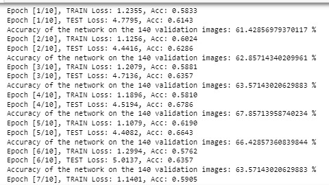

resnet18_accuracies.jpg

In the training process, we distinguish between the training and validation phase. The data, either `train_loader` or `val_loader` is iterated over and the parameter gradients are zeroed. Because Neural Network training is centered on gradient-based optimization, a forward and back propagation is performed. During forward propagation, the output of the NN is calculated. During backward propagation, the *gradients* of the outputs are calculated. Then, the statistics are calculated and presented through a print per epoch.

**Predictions on Unseen Images**

Now for the fun part: making predictions on unseen images!

To make predictions, we must first process the unseen image by applying the same transforms as the validation. We then add a batch dimension to the input data to create a Tensor, which matches the expected shape of the model’s required dimensions. Then, we perform the inference by matching the predicted class with its name.

As an example, we’re going to see if our model can correctly predict that an image from the internet displaying “h” is actually of class “h”!

```python
import torch
from torchvision import models, transforms
from PIL import Image

# Load and preprocess the unseen image
image_path = 'h_sign_lang.jpg'  # Replace with the path to your image
image = Image.open(image_path)
display(image)
preprocess = transforms.Compose([
    transforms.Resize(256),
    transforms.CenterCrop(224),
    transforms.ToTensor(),
    transforms.Normalize([0.485, 0.456, 0.406], [0.229, 0.224, 0.225])
])
# all these tasks are in preprocess variable
# in preprocess, we want to preprocess the image
preprocessed_unseen = preprocess(image)
# adding a batch dimension
batch_unseen = preprocessed_unseen.unsqueeze(0)
```

```python
# Perform inference
with torch.no_grad():
    # providing the input with input_batch
    output = model(input_batch)

# Get the predicted class
_, predicted_class = output.max(1)

# Map the predicted class to the class name
class_names = ['d', 'e', 'h', 'l', 'o', 'r', 'w']
predicted_class_name = class_names[predicted_class.item()]

print(f'The predicted class is: {predicted_class_name}')
```

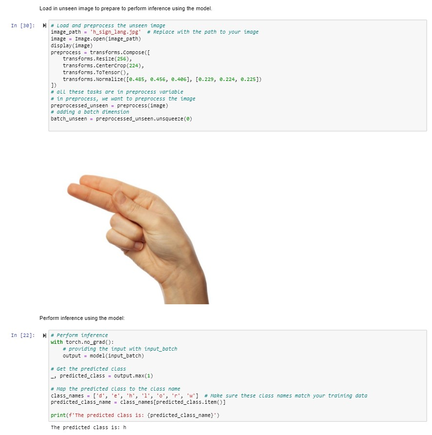

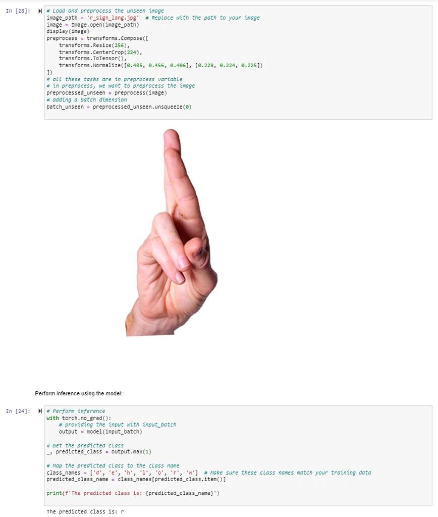

working_r_prediction.jpg

Nice! Our model correctly predicted “r” as well! Now, what about “w”?

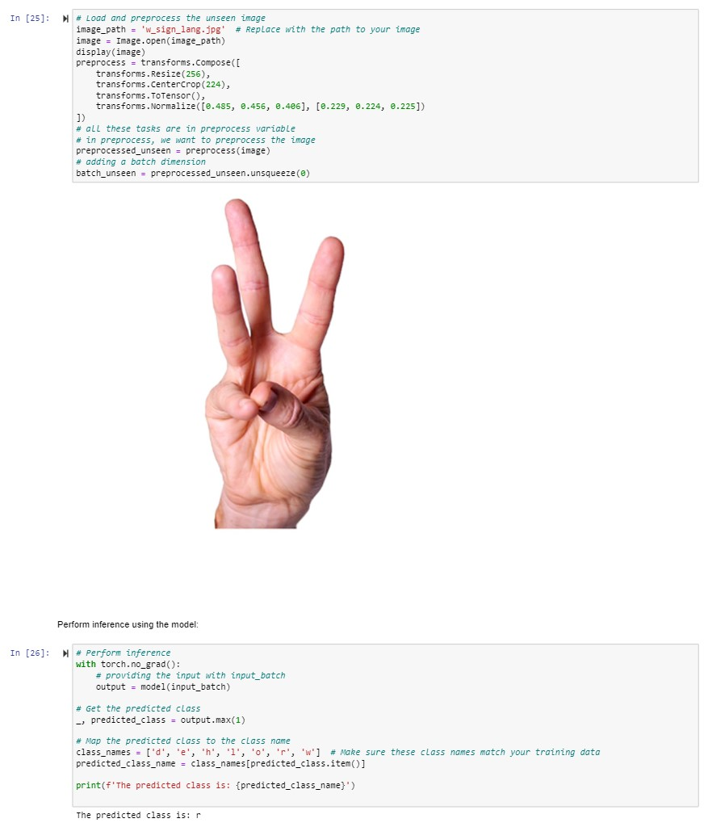

failed_w_prediction.jpg

Oh no! Our model predicted “w” to also be “r.” This may be due to “r” and “w” gestures looking fairly similar, which is what our model was trained on. Again, our model’s accuracies are not perfect, so there is bound to be errors in predictions.

To improve this, we should increase the size of our input data, introduce greater variation in the input data through the video capture process by diversifying our hand positions/backgrounds, as well as perform more transformations on the input.

# Concluding Remarks

In conclusion, this project’s successes included the fact that the TensorFlow Keras Sequential model was able to reach an accuracy of 83% and the fact that the resnet18 pre-trained model was able to read in unseen images and have accuracies of around 70%. Our main challenges lied in tweaking the code for the models to attain higher accuracies and better predictions. Researching how to go about solving our main goal also served as a tough challenge that required us to utilize resources such as our TA, and online documentation. It was a back and forth, trial and error process that we gained much from. Overall, we were able to learn brand new skills that we had not possessed prior to this project. Some of those include our knowledge of various models such as Resnet18, Resnet50, Pytorch CNN models, as well as skills such as transforming images into a CSV File. Our fundamental understandings on how image classification works and can be utilized to solve nuanced tasks like ours has grown greatly through this project.

**Sources:**

1. Adrian Tam. (2023, April 8). https://machinelearningmastery.com/training-a-pytorch-model-with-dataloader-and-dataset/
2. Code with Aarohi. (2024, January 3). https://www.youtube.com/watch?v=mn5QDKQ54dQ
3. Reza Kalantar. (2023, September 4). https://python.plainenglish.io/how-to-freeze-model-weights-in-pytorch-for-transfer-learning-step-by-step-tutorial-a533a58051ef
4. Aarohi Singla. (n.d.). https://github.com/AarohiSingla/Image-Classification-Using-Pytorch/tree/main
5. Srishiti Gureja. (2023, May 3). https://www.scaler.com/topics/pytorch/how-to-split-a-torch-dataset/
6. PyTorch. (n.d.). https://pytorch.org/tutorials/beginner/basics/data_tutorial.html
7. Nouman. (n.d.). https://blog.paperspace.com/writing-resnet-from-scratch-in-pytorch/
8. NA. (n.d.). https://colab.research.google.com/github/davidbau/how-to-read-pytorch/blob/master/notebooks/5-Pytorch-Dataloader.ipynb#scrollTo=Yf4U9ztNZpyc
9. PyTorch. (n.d.). https://pytorch.org/tutorials/beginner/introyt/modelsyt_tutorial.html
10. RunAI. (n.d.). https://www.run.ai/guides/deep-learning-for-computer-vision/pytorch-resnet#:~:text=Running%20Pretrained%20PyTorch%20ResNet%20Models,-PyTorch%20lets%20you&text=This%20will%20create%20ResNet18%2C%20an,models%20module.